# **Imoprt libraries**

```python
import pandas as pd
import numpy as np
import matplotlib.pyplot as plt
import seaborn as sns
from plotly import express as px
```

```python
# Prepocessing the data
from sklearn.preprocessing import StandardScaler,MinMaxScaler,LabelEncoder
from sklearn.impute import SimpleImputer,KNNImputer
```

```python
# Machine Learning
from sklearn.model_selection import train_test_split, cross_val_score
```

# **Load the dataset**

```python
df = pd.read_csv("heart.csv")
df.head()
```

|  | age | sex | cp | trestbps | chol | fbs | restecg | thalach | exang | oldpeak | slope | ca | thal | target |
| --- | --- | --- | --- | --- | --- | --- | --- | --- | --- | --- | --- | --- | --- | --- |
| 0 | 52 | 1 | 0 | 125 | 212 | 0 | 1 | 168 | 0 | 1.0 | 2 | 2 | 3 | 0 |
| 1 | 53 | 1 | 0 | 140 | 203 | 1 | 0 | 155 | 1 | 3.1 | 0 | 0 | 3 | 0 |
| 2 | 70 | 1 | 0 | 145 | 174 | 0 | 1 | 125 | 1 | 2.6 | 0 | 0 | 3 | 0 |
| 3 | 61 | 1 | 0 | 148 | 203 | 0 | 1 | 161 | 0 | 0.0 | 2 | 1 | 3 | 0 |
| 4 | 62 | 0 | 0 | 138 | 294 | 1 | 1 | 106 | 0 | 1.9 | 1 | 3 | 2 | 0 |

# **Exploratory Data Analysis (EDA)**

```python
df.info()
```

```
<class 'pandas.core.frame.DataFrame'>
RangeIndex: 1025 entries, 0 to 1024
Data columns (total 14 columns):
 #   Column    Non-Null Count  Dtype
---  ------    --------------  -----
 0   age       1025 non-null   int64
 1   sex       1025 non-null   int64
 2   cp        1025 non-null   int64
 3   trestbps  1025 non-null   int64
 4   chol      1025 non-null   int64
 5   fbs       1025 non-null   int64
 6   restecg   1025 non-null   int64
 7   thalach   1025 non-null   int64
 8   exang     1025 non-null   int64
 9   oldpeak   1025 non-null   float64
 10  slope     1025 non-null   int64
 11  ca        1025 non-null   int64
 12  thal      1025 non-null   int64
 13  target    1025 non-null   int64
dtypes: float64(1), int64(13)
memory usage: 112.2 KB
```

```python
df.shape
```

```
(1025, 14)
```

```python
df.describe().T
```

|  | count | mean | std | min | 25% | 50% | 75% | max |
| --- | --- | --- | --- | --- | --- | --- | --- | --- |
| age | 1025.0 | 54.434146 | 9.072290 | 29.0 | 48.0 | 56.0 | 61.0 | 77.0 |
| sex | 1025.0 | 0.695610 | 0.460373 | 0.0 | 0.0 | 1.0 | 1.0 | 1.0 |
| cp | 1025.0 | 0.942439 | 1.029641 | 0.0 | 0.0 | 1.0 | 2.0 | 3.0 |
| trestbps | 1025.0 | 131.611707 | 17.516718 | 94.0 | 120.0 | 130.0 | 140.0 | 200.0 |
| chol | 1025.0 | 246.000000 | 51.592510 | 126.0 | 211.0 | 240.0 | 275.0 | 564.0 |
| fbs | 1025.0 | 0.149268 | 0.356527 | 0.0 | 0.0 | 0.0 | 0.0 | 1.0 |
| restecg | 1025.0 | 0.529756 | 0.527878 | 0.0 | 0.0 | 1.0 | 1.0 | 2.0 |
| thalach | 1025.0 | 149.114146 | 23.005724 | 71.0 | 132.0 | 152.0 | 166.0 | 202.0 |
| exang | 1025.0 | 0.336585 | 0.472772 | 0.0 | 0.0 | 0.0 | 1.0 | 1.0 |
| oldpeak | 1025.0 | 1.071512 | 1.175053 | 0.0 | 0.0 | 0.8 | 1.8 | 6.2 |
| slope | 1025.0 | 1.385366 | 0.617755 | 0.0 | 1.0 | 1.0 | 2.0 | 2.0 |
| ca | 1025.0 | 0.754146 | 1.030798 | 0.0 | 0.0 | 0.0 | 1.0 | 4.0 |
| thal | 1025.0 | 2.323902 | 0.620660 | 0.0 | 2.0 | 2.0 | 3.0 | 3.0 |
| target | 1025.0 | 0.513171 | 0.500070 | 0.0 | 0.0 | 1.0 | 1.0 | 1.0 |

```python
df['age'].min(), df['age'].max()
```

```
(29, 77)
```

```python
df.isnull().sum()
```

```
age         0
sex         0
cp          0
trestbps    0
chol        0
fbs         0
restecg     0
thalach     0
exang       0
oldpeak     0
slope       0
ca          0
thal        0
target      0
dtype: int64
```

```python
df.duplicated().sum()
```

```
723
```

```python
duplicated_rows = df[df.duplicated(keep=False)]

print("Duplicated Rows (all instances):")
print(duplicated_rows)
```

```
Duplicated Rows (all instances):
      age  sex  cp  trestbps  chol  fbs  restecg  thalach  exang  oldpeak  \
0      52    1   0       125   212    0        1      168      0      1.0
1      53    1   0       140   203    1        0      155      1      3.1
2      70    1   0       145   174    0        1      125      1      2.6
3      61    1   0       148   203    0        1      161      0      0.0
4      62    0   0       138   294    1        1      106      0      1.9
...   ...  ...  ..       ...   ...  ...      ...      ...    ...      ...
1020   59    1   1       140   221    0        1      164      1      0.0
1021   60    1   0       125   258    0        0      141      1      2.8
1022   47    1   0       110   275    0        0      118      1      1.0
1023   50    0   0       110   254    0        0      159      0      0.0
1024   54    1   0       120   188    0        1      113      0      1.4

      slope  ca  thal  target
0         2   2     3       0
1         0   0     3       0
2         0   0     3       0
3         2   1     3       0
4         1   3     2       0
...     ...  ..   ...     ...
1020      2   0     2       1
1021      1   1     3       0
1022      1   1     2       0
1023      2   0     2       1
1024      1   1     3       0

[1025 rows x 14 columns]
```

```python
# Calculate Q1 (25th percentile) and Q3 (75th percentile)
Q1 = df['age'].quantile(0.25)
Q3 = df['age'].quantile(0.75)

# Calculate IQR (Interquartile Range)
IQR = Q3 - Q1

# Define lower and upper bounds for outliers
lower_bound = Q1 - 1.5 * IQR
upper_bound = Q3 + 1.5 * IQR

# Identify outliers
outliers = df[(df['age'] < lower_bound) | (df['age'] > upper_bound)]

print("Outliers detected:")
print(outliers)
```

```
Outliers detected:
Empty DataFrame
Columns: [age, sex, cp, trestbps, chol, fbs, restecg, thalach, exang, oldpeak, slope, ca, thal, target]
Index: []
```

# **Visualization**

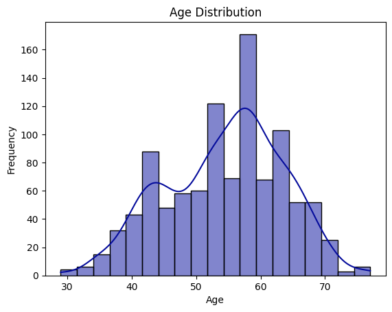

```python
# Define custom colors
custom_colors = ["#050C9C", "#3572EF", "#3ABEF9"]

# Plot the histogram with custom colors
sns.histplot(df['age'], kde=True, color="#050C9C", palette=custom_colors)
plt.title("Age Distribution")
plt.xlabel("Age")
plt.ylabel("Frequency")
plt.show()
```

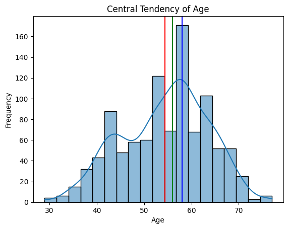

```
Mean 54.43414634146342
Median 56.0
Mode 0    58
Name: age, dtype: int64
```

```python
# Plot the mean, Median and mode of age column
sns.histplot(df['age'], kde=True)
plt.axvline(df['age'].mean(), color='Red')
plt.axvline(df['age'].median(), color= 'Green')
plt.axvline(df['age'].mode()[0], color='Blue')
plt.title("Central Tendency of Age")
plt.xlabel("Age")
plt.ylabel("Frequency")
plt.show()

# print the value of mean, median and mode of age column
print('Mean', df['age'].mean())
print('Median', df['age'].median())
print('Mode', df['age'].mode())
```

```python
# plot the histogram of age column

df['sex'] = df['sex'].map({1: 'male', 0: 'female'})

fig = px.histogram(
    df,
    x='age',
    color='sex',

    title='Age Distribution by Sex',
    width=600,
    height=500
)

fig.show()
```

[interactive chart not shown]

```python
# Find the values of sex column
df['sex'].value_counts()
```

```
sex
male      713
female    312
Name: count, dtype: int64
```

```python
# Find the values count of age column grouping by sex column
df.groupby('sex')['age'].value_counts()
```

```
sex     age
female  62     24
        58     21
        63     17
        54     15
        55     15
               ..
male    69      6
        29      4
        34      3
        37      3
        77      3
Name: count, Length: 73, dtype: int64
```

```python
# value count of cp column
df['cp'].value_counts()
```

```
cp
0    497
2    284
1    167
3     77
Name: count, dtype: int64
```

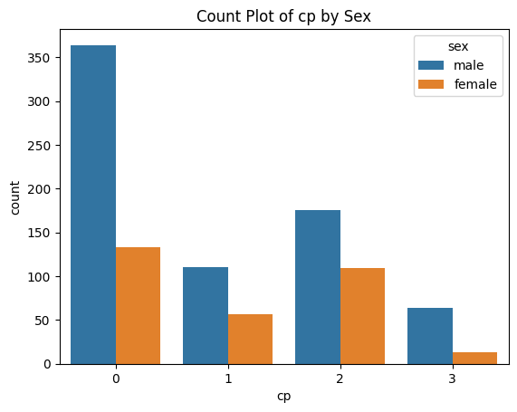

```python
# Creating the count plot of cp column
sns.countplot(df, x='cp', hue='sex').set_title('Count Plot of cp by Sex')
plt.show()
```

```python
# Draw the plot of age column group by cp column

fig = px.histogram(data_frame=df, x='age', color='cp',title= 'Age distribution by CP ',
                   width=600 , height=500)
fig.show()
```

[interactive chart not shown]

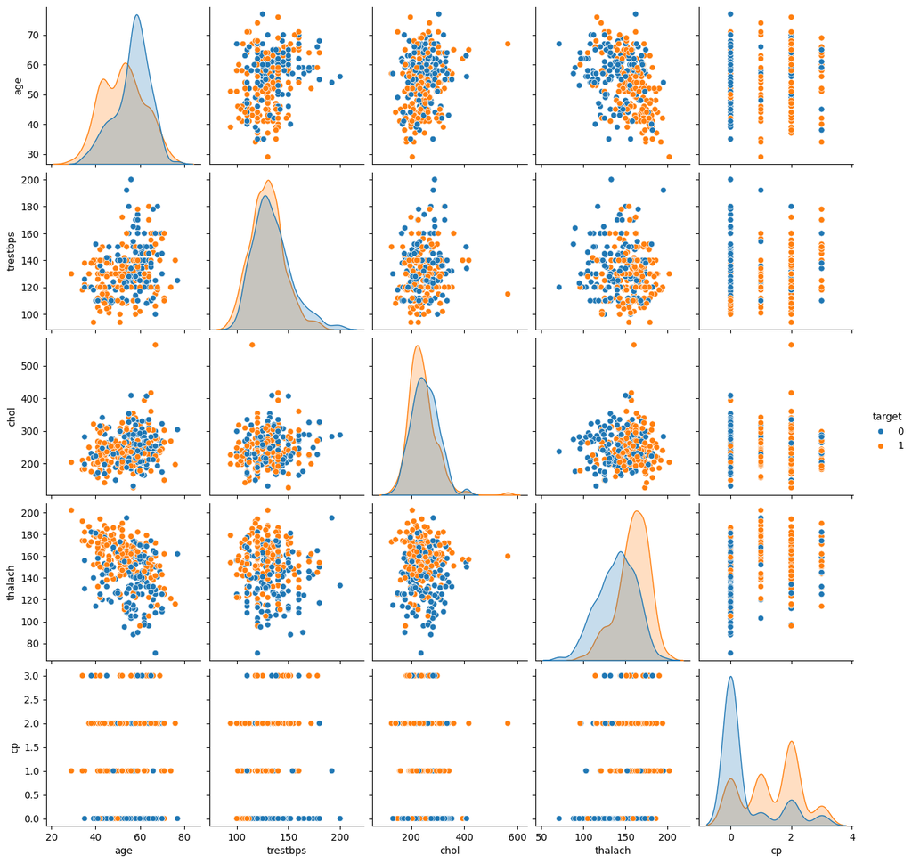

```python
sns.pairplot(df[['age','trestbps','chol','thalach','target','cp']], hue = 'target')
plt.show()
```

# **Machine learning models**

```python
df.columns
```

```
Index(['age', 'sex', 'cp', 'trestbps', 'chol', 'fbs', 'restecg', 'thalach',
       'exang', 'oldpeak', 'slope', 'ca', 'thal', 'target'],
      dtype='object')
```

```python
df['target'].unique()
```

```
array([0, 1])
```

```python
df['target'].value_counts()
```

```
target
1    526
0    499
Name: count, dtype: int64
```

The Target column is my predicted attribute. I will use this column to predict the heart disease. The unique values in this column are: [0,1] which states that the presence of heart diseases.

0 = no heart disease. 1 = Heart Disease.

```python
# split the data into X and y
X= df.drop('target', axis=1)
y = df['target']
Label_Encoder = LabelEncoder()

for col in X.columns:
    if X[col].dtype == 'object' or X[col].dtype == 'category':
        X[col] = Label_Encoder.fit_transform(X[col])
    else:
        pass


# split the data into train and test
X_train, X_test, y_train, y_test = train_test_split(X, y, test_size=0.2, random_state=101)
```

a.logistic regression.

b.KNN

c.SVM

d.Decision Tree

e.Random Forest

```python
X_test.head()
```

|  | age | sex | cp | trestbps | chol | fbs | restecg | thalach | exang | oldpeak | slope | ca | thal |
| --- | --- | --- | --- | --- | --- | --- | --- | --- | --- | --- | --- | --- | --- |
| 909 | 50 | 1 | 0 | 144 | 200 | 0 | 0 | 126 | 1 | 0.9 | 1 | 0 | 3 |
| 748 | 44 | 1 | 2 | 120 | 226 | 0 | 1 | 169 | 0 | 0.0 | 2 | 0 | 2 |
| 919 | 38 | 1 | 3 | 120 | 231 | 0 | 1 | 182 | 1 | 3.8 | 1 | 0 | 3 |
| 975 | 39 | 1 | 0 | 118 | 219 | 0 | 1 | 140 | 0 | 1.2 | 1 | 0 | 3 |
| 246 | 54 | 1 | 1 | 192 | 283 | 0 | 0 | 195 | 0 | 0.0 | 2 | 1 | 3 |

```python
# improt All models.
from sklearn.linear_model import LogisticRegression
from sklearn.neighbors import KNeighborsClassifier
from sklearn.svm import SVC
from sklearn.tree import DecisionTreeClassifier, plot_tree
from sklearn.ensemble import RandomForestClassifier

#importing pipeline
from sklearn.pipeline import Pipeline

# import metrics
from sklearn.metrics import accuracy_score, confusion_matrix, classification_report, mean_absolute_error, mean_squared_error
from sklearn.model_selection import train_test_split,GridSearchCV, cross_val_score
```

```python
# Define the models to evaluate
models = [
    ('Logistic Regression', LogisticRegression(random_state=101)),
    ('KNeighbors Classifier', KNeighborsClassifier()),
    ('Decision Tree Classifier', DecisionTreeClassifier(random_state=101)),
    ('Random Forest', RandomForestClassifier(random_state=101)),
    ('Support Vector Machine', SVC(random_state=101))
]

best_model = None
best_accuracy = 0.0

# Iterate over the models and evaluate their performance
for name, model in models:
    # Create a pipeline for each model
    pipeline = Pipeline([
        ('imputer', SimpleImputer(strategy='most_frequent')),
        ('model', model)
    ])

    # Perform cross-validation
    scores = cross_val_score(pipeline, X_train, y_train, cv=5)

    # Calculate mean accuracy
    mean_accuracy = scores.mean()

    # Fit the pipeline on the training data
    pipeline.fit(X_train, y_train)

    # Make predictions on the test data
    y_pred = pipeline.predict(X_test)

    # Calculate accuracy score
    accuracy = accuracy_score(y_test, y_pred)

    # Print the performance metrics
    print("Model:", name)
    print("Cross Validation Accuracy: ", mean_accuracy)
    print("Test Accuracy: ", accuracy)
    print()

    # Check if the current model has the best accuracy
    if accuracy > best_accuracy:
        best_accuracy = accuracy
        best_model = pipeline

# Retrieve the best model
print("Best Model:", best_model)
```

```
Model: Logistic Regression
Cross Validation Accuracy:  0.8426829268292682
Test Accuracy:  0.8634146341463415

Model: KNeighbors Classifier
Cross Validation Accuracy:  0.7134146341463415
Test Accuracy:  0.7317073170731707

Model: Decision Tree Classifier
Cross Validation Accuracy:  0.9902439024390244
Test Accuracy:  0.9853658536585366

Model: Random Forest
Cross Validation Accuracy:  0.9902439024390244
Test Accuracy:  1.0

Model: Support Vector Machine
Cross Validation Accuracy:  0.6878048780487804
Test Accuracy:  0.6829268292682927

Best Model: Pipeline(steps=[('imputer', SimpleImputer(strategy='most_frequent')),
                ('model', RandomForestClassifier(random_state=101))])
```

# Evaluation of the model

```python
df.head()
```

|  | age | sex | cp | trestbps | chol | fbs | restecg | thalach | exang | oldpeak | slope | ca | thal | target |
| --- | --- | --- | --- | --- | --- | --- | --- | --- | --- | --- | --- | --- | --- | --- |
| 0 | 52 | male | 0 | 125 | 212 | 0 | 1 | 168 | 0 | 1.0 | 2 | 2 | 3 | 0 |
| 1 | 53 | male | 0 | 140 | 203 | 1 | 0 | 155 | 1 | 3.1 | 0 | 0 | 3 | 0 |
| 2 | 70 | male | 0 | 145 | 174 | 0 | 1 | 125 | 1 | 2.6 | 0 | 0 | 3 | 0 |
| 3 | 61 | male | 0 | 148 | 203 | 0 | 1 | 161 | 0 | 0.0 | 2 | 1 | 3 | 0 |
| 4 | 62 | female | 0 | 138 | 294 | 1 | 1 | 106 | 0 | 1.9 | 1 | 3 | 2 | 0 |

```python
categorical_cols = ['cp', 'slope','thal', 'exang', 'restecg','fbs', 'ca', 'sex']
```

```python
def evaluate_classification_models(X, y, categorical_columns):
    # Encode categorical columns
    X_encoded = X.copy()
    label_encoders = {}
    for col in categorical_columns:
        label_encoders[col] = LabelEncoder()
        X_encoded[col] = label_encoders[col].fit_transform(X[col])

    # Split data into train and test sets
    X_train, X_test, y_train, y_test = train_test_split(X_encoded, y, test_size=0.3, random_state=101)

    # Define models
    models = {
        "Logistic Regression": LogisticRegression(),
        "KNN": KNeighborsClassifier(),
        "SVM": SVC(),
        "Decision Tree": DecisionTreeClassifier(),
        "Random Forest": RandomForestClassifier()
    }

    # Train and evaluate models
    results = {}
    best_model = None
    best_accuracy = 0.0
    for name, model in models.items():
        model.fit(X_train, y_train)
        y_pred = model.predict(X_test)
        accuracy = accuracy_score(y_test, y_pred)
        results[name] = accuracy
        if accuracy > best_accuracy:
            best_accuracy = accuracy
            best_model = name

    return results, best_model


# Example usage:
results, best_model = evaluate_classification_models(X, y, categorical_cols)
print("Model accuracies:", results)
print("Best model:", best_model)
```

```
Model accuracies: {'Logistic Regression': 0.8474025974025974, 'KNN': 0.7207792207792207, 'SVM': 0.6883116883116883, 'Decision Tree': 0.9577922077922078, 'Random Forest': 1.0}
Best model: Random Forest
```

# **Conclusion**

After thorough data exploration, we trained several machine learning models including Logistic Regression, Decision Tree, Random Forest,SVM and KNN. The models achieved the following accuracies:

Decision Tree : 0.95

Random Forest : 0.99

KNN : 0.72

SVM: 0.69

Among these models, Random Forest performed the best with an accuracy of 99% making it the top choice for predicting heart diseases based on the given features.